# Why molecules repel each other

Alternative title: How Bricks Work. In this post, I do some quantum chemistry calculations to more carefully investigate why molecules bounce off each other, as well as providing some heuristic arguments about it.

Things to do before publication:

- say something about the Lieb, "Stability of matter" result
- comment on how this is relevant to the interactions between atoms inside molecules too
- talk about how electron KE plays into all this
- say something about epistemic modesty

For a long time, my pet peeve has been when people explain the fact that molecules bounce off each other (or, equivalently, that I don't sink through my chair) by saying that molecules have negative charges on the outside that repel each other.

This claim appears a million places, but I'll pick on a few:

Clayden et al, "Organic Chemistry", 2nd edition, p108:

> Molecules are coated with a layer of electrons which occupy bonding and maybe non- bonding orbitals. As a result the surface of each molecule is negatively charged and by and large molecules repel each other.

More ironically, Natalie Angier in "The Canon" writes about public understanding of science:

> A fair question to interject here is: Need we do anything at all? Does it matter if the great majority of people know little or nothing about science or the scientific mindset? If the average Joe or Sophie doesn't know the name of the closest star (the sun), or whether tomatoes have genes (they do), or why your hand can't go through a tabletop (because the electrons in each repel each other), what difference does it make?

As far as I can tell, this explanation is basically false.

So if you have to give a simple explanation of why molecules repel each other, I think the best one is "Nuclei repel each other. Sometimes, atoms can bond, which allows electrons to get into sufficiently energetically favorable states that it's energetically 'worth it' for the nuclei to be near each other. But if this doesn't happen, then as your molecules get closer, even though electronic energy monotonically decreases, the nuclear repulsion gets stronger and stronger and causes the molecules to bounce off each other."

To see evidence of this, you can look at all the calculations that I did below.

Here are some relevant arguments and intuitions.

- **Actual calculations.** Below, I calculate total energy as a function of distance for the following systems: two H2 molecules, two He atoms, and one NH3 and one BH3. For each, you'll observe that as the molecules get closer, the electron energy monotonically decreases, and the nuclear energy monotonically increases, adding up to a net repulsion at short ranges.
- **He2 vs Be**. Suppose I have two He atoms and I move their nuclei on top of each other. From the perspective of the electrons, this is the same as them being the electrons of a Be atom. Be atoms have a ground state energy more than 2x lower than He atoms. This is a specific instance of the general statement that as molecules move closer together, electron energy decreases.
- **Analogy to the shell theorem.** It's true that when I have two molecules near each other, their electrons are nearby each other and repelling each other. But their electrons are also attracted to the nuclei of the other molecule, and in fact the electrons of the first molecule are closer to the nuclei of the other molecule than they are to around half of the second molecule's electron. This is reminiscent of the [shell theorem](https://physics.stackexchange.com/questions/428454/a-question-about-shell-theorem-and-a-question-about-center-of-charge), which states that you can treat a spherically symmetric distribution of charge as a point charge at the center of the distribution. That theorem doesn't totally apply here, because we have no particular guarantee of spherical symmetry, but it points to why the "the electrons repel each other" intuition is wrong.

In the rest of this notebook, I demonstrate this with a variety of calculations. The casual reader might want to only look at the plots and ignore the code. All distances are in Angstroms and all energies are in Hartrees.

```python
from pyscf import gto, scf, fci
import matplotlib.pyplot as plt
import numpy as np

plt.rcParams['figure.figsize'] = [10, 5]
```

```python
# Various utility functions

def energy_components(mf):
    # Given an optimized HF state, determine the different components of the energy.
    # This function is based on energy_elec in PySCF's scf.hf module.
    dm = mf.make_rdm1()

    ke_op = mf.mol.intor('int1e_kin')
    ke = np.einsum('ij,ji->', ke_op, dm)

    nuc_op = mf.mol.intor('int1e_nuc')
    nuc = np.einsum('ij,ji->', nuc_op, dm)

    vhf = mf.get_veff(mf.mol, dm)
    e_coul = np.einsum('ij,ji->', vhf, dm) * .5
    # returns: electron KE, electron-nuclear attraction, electron-electron repulsion,
    # nucleon-nucleon repulsion
    return (ke, nuc, e_coul, mf.energy_nuc())

def do_hf(mol_str, basis="ccpvdz"):
    return scf.RHF(gto.M(atom = mol_str, basis = basis, verbose=0)).run()
```

## Electron states around Be vs He2

Below, I calculate the components of the energy for two He atoms at a distance of 0.02Å, which is ridiculously close. (If you put them literally on top of each other, you get a divide-by-zero error while calculating nucleon-nucleon repulsion.) The first three numbers are the electron KE, nuclear PE, and electron-electron PE. Note that they are very similar. The final number is the nucleon-nucleon repulsion energy, which is obviously extremely high for the He2 and zero for the Be.

```python
basically_be = do_hf("He 0 0 0; He 0 0 0.02", "ccpv5z")
print(energy_components(basically_be))
print(energy_components(do_hf("Be 0 0 0")))
```

```
(14.582406171014135, -33.73372314569693, 4.719902900486772, 105.835442184)
(14.57235366893493, -33.6342996089171, 4.489608309028773, 8e-200)
```

## Calculations of energies as molecules approach

### Two He2 atoms

See the graph below. As the He atoms approach, the major increasing factor contributing to repulsion is the nucleon-nucleon energy.

```python
def he2_hf(r):
    return do_hf('He 0 0 0; He 0 0 {r}'.format(r=r))

rs = np.linspace(0.1, 3, 30)
he2_energies = np.array([energy_components(he2_hf(r)) for r in rs])
```

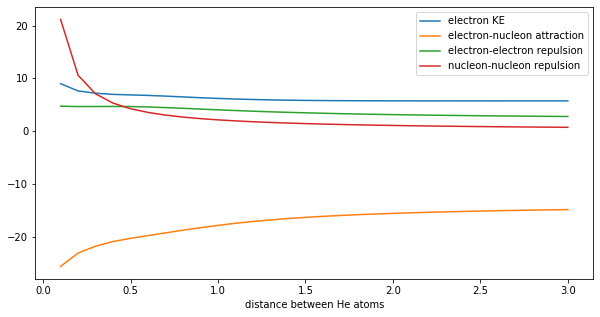

```python
plt.plot(rs, he2_energies[:,0], label="electron KE")
plt.plot(rs, he2_energies[:,1], label='electron-nucleon attraction')
plt.plot(rs, he2_energies[:,2], label='electron-electron repulsion')
plt.plot(rs, he2_energies[:,3], label='nucleon-nucleon repulsion')
plt.legend()
plt.xlabel("distance between He atoms")
```

And here's a plot where all the electron energy terms have been added together:

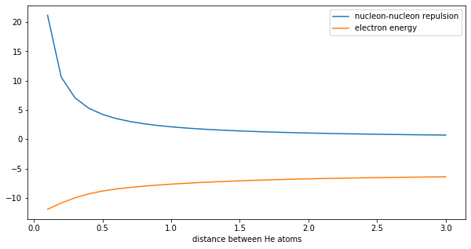

```python
plt.plot(rs, he2_energies[:,3], label='nucleon-nucleon repulsion')
plt.plot(rs, np.sum(he2_energies[:,:3], axis=1), label="electron energy")
plt.legend()
plt.xlabel("distance between He atoms")
```

### Bond length in H2

You can also look at the energy of H2 and observe that as you decrease the bond length, electron energy decreases, nucleon-nucleon energy increases, and they add up to give us that curve we know and love with the minima at 0.74Å.

```python
def h2_hf(r):
    return do_hf('H 0 0 0; H 0 0 {r}'.format(r=r))

rs = np.linspace(0.1, 3, 30)
h2_energies = np.array([energy_components(h2_hf(r)) for r in rs])
```

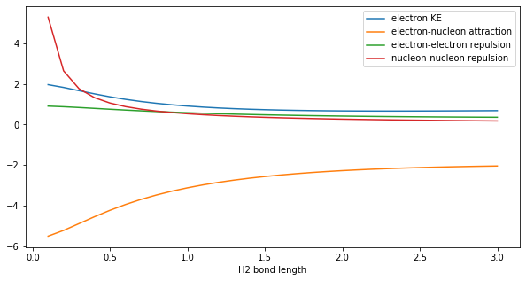

```python
plt.plot(rs, h2_energies[:,0], label="electron KE")
plt.plot(rs, h2_energies[:,1], label='electron-nucleon attraction')
plt.plot(rs, h2_energies[:,2], label='electron-electron repulsion')
plt.plot(rs, h2_energies[:,3], label='nucleon-nucleon repulsion')
plt.legend()
plt.xlabel("H2 bond length")
```

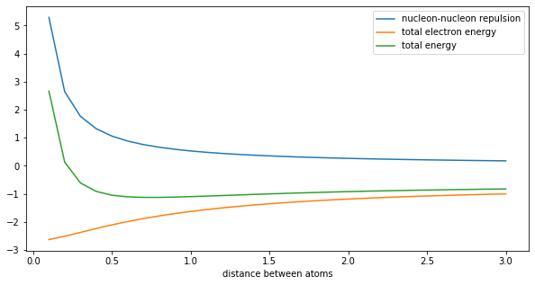

```python
plt.plot(rs, h2_energies[:,3], label='nucleon-nucleon repulsion')
plt.plot(rs, np.sum(h2_energies[:,:3], axis=1), label="total electron energy")
plt.plot(rs, np.sum(h2_energies, axis=1), label="total energy")
plt.xlabel("distance between atoms")
plt.legend()
```

### Two H2 molecules

Here's the same thing, but with two H2 molecules approaching each other.

```python
def h2_at(z):
    return "H 0 0 {z}; H 0.74 0 {z}".format(z=z)

rs = np.linspace(0.74, 5, 30)**1.5
h2_approach_energies = np.array([energy_components(do_hf(h2_at(0) + ";" + h2_at(r)))
                                for r in rs])
```

[figure not shown]

```python
plt.plot(rs, h2_approach_energies[:,3], label='nucleon-nucleon repulsion')
plt.plot(rs, np.sum(h2_approach_energies[:,:3], axis=1), label="electron energy")
plt.xlabel("distance between H2 molecules")
plt.legend()
```

### NH3 and BH3

(this example picked because it appears in Clayden et al's book right after the passage I quoted from it)

```python
def ammonia_at(z):
    # Returns a string describing an ammonia molecule with the N at (0,0,z),
    # oriented with H below N.

    # This is an approximation of the optimal geometry of NH3, because I
    # didn't want to figure out how to convert "102 pm bonds at 109 degrees"
    # into Cartesian coordinates.
    return """N 0 0 {n_z}; H 0.9 0 {h_z};
            H -0.45 0.78 {h_z}; H -0.45 -0.78 {h_z}""".format(n_z=z, h_z=z - 0.1)
```

```python
# To make sure I didn't totally mess up the ammonia geometry, let's check the HF
# energy. The true HF energy with this basis set is around -56.1917.
sum(energy_components(do_hf(ammonia_at(0))))
```

```
-56.15892700040888
```

```python
def bh3_at(z):
    # Returns a string describing an BH3 molecule with the B at (0,0,z),
    # with the hydrogens all on the same z plane as the B.

    return """B 0 0 {z}; H 1.19 0 {z};
            H -0.59 1.03 {z}; H -0.59 -1.03 {z}""".format(z=z)
```

```python
zs = np.linspace(0.5, 10, 30)
nh3_bh3_approach_energies = \
    np.array([energy_components(do_hf(ammonia_at(0) + "; " + bh3_at(z)))
                                for z in zs])
```

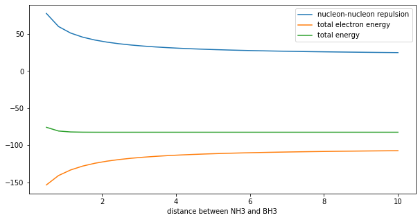

```python
plt.plot(zs, nh3_bh3_approach_energies[:,3], label='nucleon-nucleon repulsion')
plt.plot(zs, np.sum(nh3_bh3_approach_energies[:,:3], axis=1), label="total electron energy")
plt.plot(zs, np.sum(nh3_bh3_approach_energies, axis=1), label="total energy")
plt.xlabel("distance between NH3 and BH3")
plt.legend()
```

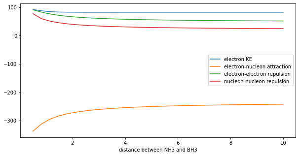

```python
plt.plot(zs, nh3_bh3_approach_energies[:,0], label="electron KE")
plt.plot(zs, nh3_bh3_approach_energies[:,1], label='electron-nucleon attraction')
plt.plot(zs, nh3_bh3_approach_energies[:,2], label='electron-electron repulsion')
plt.plot(zs, nh3_bh3_approach_energies[:,3], label='nucleon-nucleon repulsion')

plt.xlabel("distance between NH3 and BH3")
plt.legend()
```